# Homework 3 - Clustering

## Case Summary

East-West Airlines is trying to learn more about its customers. Key issues are their flying patterns, earning and use of frequent flyer rewards, and use of the airline credit card. The task is to identify customer segments via clustering. The file EastWestAirlines.xls contains information on 4000 passengers who belong to an airline’s frequent flier program. For each passenger the data include information on their mileage history and on different ways they accrued or spent miles in the last year. **The goal is to try to identify clusters of passengers that have similar charactersitics for the purpose of targeting different segments for different types of mileage offers.**

Please prepare a notebook including answers to each of the following questions:

1. Apply hierarchical clustering with Euclidean distance and complete linkage. How many clusters appear to be appropriate? (*25 points*)
2. Compare the cluster centroids to characterize the different clusters and try to give each cluster a label. (*20 points*)
3. To check the stability of the clusters, remove a random 5% of the data (by taking a random sample of 95% of the records, namely 200 records), and repeat the analysis. Does the same picture emerge? Use 425 as the seed. (*10 points*)
4. Use k-means algorithm with the number of clusters you found in part (a). Does the same picture emerge? (*25 points*)
5. Which clusters would you target for offers, and what type of offers would you target to customers in that cluster? (*20 points*)

Below we provided you with a list of libraries that might be useful for your case study. This list is only a sample of what you might need; you are free to use any additional library serving your purpose.

**The homework is due Sunday, October 23 midnight.**

## Data Description

- **Field Name**=ID#; **Data Type**=NUMBER; **Description**=Unique ID
- **Field Name**=Balance; **Data Type**=NUMBER; **Description**=Number of miles eligible for award travel
- **Field Name**=Qual_miles; **Data Type**=NUMBER; **Description**=Number of miles counted as qualifying for Topflight status
- **Field Name**=cc1_miles; **Data Type**=CHAR; **Description**=Number of miles earned with freq. flyer credit card in the past 12 months:
- **Field Name**=cc2_miles; **Data Type**=CHAR; **Description**=Number of miles earned with Rewards credit card in the past 12 months:
- **Field Name**=cc3_miles; **Data Type**=CHAR; **Description**=Number of miles earned with Small Business credit card in the past 12 months:
- For cc1_miles,cc2_miles and cc3_miles bins mean following ranges:

  ```
    - 1 = under 5,000
    - 2 = 5,000 - 10,000
    - 3 = 10,001 - 25,000
    - 4 = 25,001 - 50,000
    - 5 = over 50,000
  ```

- **Field Name**=Bonus_miles; **Data Type**=NUMBER; **Description**=Number of miles earned from non-flight bonus transactions in the past 12 months
- **Field Name**=Bonus_trans; **Data Type**=NUMBER; **Description**=Number of non-flight bonus transactions in the past 12 months
- **Field Name**=Flight_miles_12mo; **Data Type**=NUMBER; **Description**=Number of flight miles in the past 12 months
- **Field Name**=Flight_trans_12; **Data Type**=NUMBER; **Description**=Number of flight transactions in the past 12 months
- **Field Name**=Days_since_enroll; **Data Type**=NUMBER; **Description**=Number of days since Enroll_date
- **Field Name**=Award?; **Data Type**=NUMBER; **Description**=Dummy variable for Last_award (1=not null, 0=null)

# Sample Libraries

```python
import pandas as pd
import numpy as np
import matplotlib.pyplot as plt
import seaborn as sns
from sklearn.cluster import KMeans, AgglomerativeClustering, DBSCAN
import scipy.cluster.hierarchy as sch
```

# Data Preprocessing

```python
data=pd.read_excel('EastWestAirlines.xls',sheet_name='data')
```

## Drop Outliers

[figure not shown]

```python
def detect_outliers(df,features):
    from collections import Counter

    outlier_indices = []
    for c in features:
        # 1st quartile
        Q1 = np.percentile(df[c],25)
        # 3rd quartile
        Q3 =np.percentile(df[c],75)
        # IQR
        IQR = Q3 - Q1

        #Outlier Step
        outlier_step = IQR * 1.5
        # Detect outlier and their indices
        outlier_list_col = df[(df[c] <Q1 - outlier_step) | (df[c] > Q3 + outlier_step)].index
        #store indices
        outlier_indices.extend(outlier_list_col)

    outlier_indices = Counter(outlier_indices)
    multiple_outliers = list(i for i,v in outlier_indices.items() if v > 2)
    return multiple_outliers
```

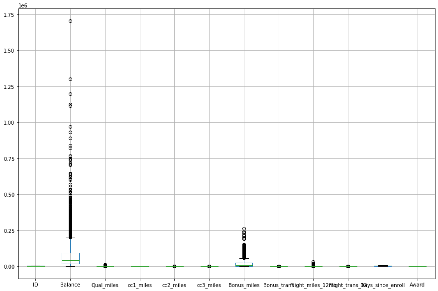

```python
plt.figure(figsize=(15,10))
data.boxplot()
```

```python
data = data.drop(detect_outliers(data,["Balance","Qual_miles","Bonus_trans","Flight_miles_12mo","Flight_trans_12","Days_since_enroll"]),axis = 0).reset_index(drop = True)
```

```python
data.head(5)
```

|  | ID | Balance | Qual_miles | cc1_miles | cc2_miles | cc3_miles | Bonus_miles | Bonus_trans | Flight_miles_12mo | Flight_trans_12 | Days_since_enroll | Award |
| --- | --- | --- | --- | --- | --- | --- | --- | --- | --- | --- | --- | --- |
| 0 | 1 | 28143 | 0 | 1 | 1 | 1 | 174 | 1 | 0 | 0 | 7000 | 0 |
| 1 | 2 | 19244 | 0 | 1 | 1 | 1 | 215 | 2 | 0 | 0 | 6968 | 0 |
| 2 | 3 | 41354 | 0 | 1 | 1 | 1 | 4123 | 4 | 0 | 0 | 7034 | 0 |
| 3 | 4 | 14776 | 0 | 1 | 1 | 1 | 500 | 1 | 0 | 0 | 6952 | 0 |
| 4 | 5 | 97752 | 0 | 4 | 1 | 1 | 43300 | 26 | 2077 | 4 | 6935 | 1 |

## Drop Meanless Column

```python
data.drop(columns=["ID"],inplace=True)
```

## Scaling Data

[figure not shown]

```python
from sklearn.preprocessing import normalize
data_scaled = normalize(data)
data_scaled = pd.DataFrame(data_scaled, columns=data.columns)
data_scaled.head()
```

|  | Balance | Qual_miles | cc1_miles | cc2_miles | cc3_miles | Bonus_miles | Bonus_trans | Flight_miles_12mo | Flight_trans_12 | Days_since_enroll | Award |
| --- | --- | --- | --- | --- | --- | --- | --- | --- | --- | --- | --- |
| 0 | 0.970414 | 0.0 | 0.000034 | 0.000034 | 0.000034 | 0.006000 | 0.000034 | 0.000000 | 0.000000 | 0.241371 | 0.000000 |
| 1 | 0.940209 | 0.0 | 0.000049 | 0.000049 | 0.000049 | 0.010504 | 0.000098 | 0.000000 | 0.000000 | 0.340437 | 0.000000 |
| 2 | 0.981113 | 0.0 | 0.000024 | 0.000024 | 0.000024 | 0.097817 | 0.000095 | 0.000000 | 0.000000 | 0.166880 | 0.000000 |
| 3 | 0.904428 | 0.0 | 0.000061 | 0.000061 | 0.000061 | 0.030605 | 0.000061 | 0.000000 | 0.000000 | 0.425527 | 0.000000 |
| 4 | 0.912226 | 0.0 | 0.000037 | 0.000009 | 0.000009 | 0.404078 | 0.000243 | 0.019383 | 0.000037 | 0.064718 | 0.000009 |

# Question 1

Apply hierarchical clustering with Euclidean distance and complete linkage. How many clusters appear to be appropriate?

### Dendrogram

A Dendrogram is a type of tree diagram showing hierarchical relationships between different sets of data. [More Information](https://www.kdnuggets.com/2019/09/hierarchical-clustering.html)

#### Determine Cluster Number With Dendrogram

The greatest distance that can be vertically spaced without crossing any horizontal lines is sought. The lines in the diagram are counted and the optimal number of clusters is determined. The cluster number for this dataset will be 3.[More Information](https://www.kdnuggets.com/2019/09/hierarchical-clustering.html)

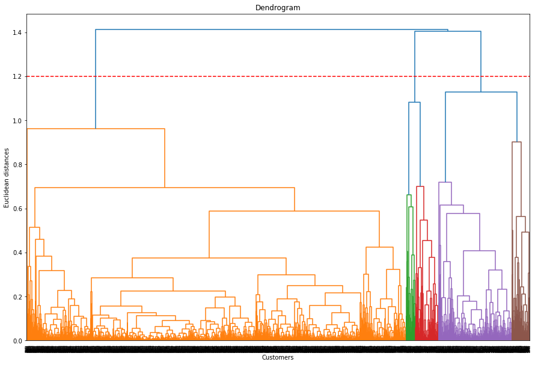

```python
plt.figure(figsize=(15,10))
dendrogram = sch.dendrogram(sch.linkage(data_scaled, method  = "complete"))
plt.title('Dendrogram')
plt.xlabel('Customers')
plt.ylabel('Euclidean distances')
plt.axhline(y=1.2, color='r', linestyle='--')

plt.show()
```

#### Determine Cluster Number With Silhoutte Score

Silhouette Score = (b-a)/max(a,b)

where

a= average intra-cluster distance i.e the average distance between each point within a cluster.

b= average inter-cluster distance i.e the average distance between all clusters.

Silhouette Coefficient or silhouette score is a metric used to calculate the goodness of a clustering technique. Its value ranges from -1 to 1.

1: Means clusters are well apart from each other and clearly distinguished.

0: Means clusters are indifferent, or we can say that the distance between clusters is not significant.

-1: Means clusters are assigned in the wrong way.[More Information](https://towardsdatascience.com/silhouette-coefficient-validating-clustering-techniques-e976bb81d10c)

```python
from sklearn.metrics import silhouette_score

for clusterCount in range(2,12):
    cluster = AgglomerativeClustering(n_clusters=clusterCount, affinity='euclidean', linkage='complete')
    y_h=cluster.fit_predict(data_scaled)
    silhouette_avg = silhouette_score(data_scaled,y_h)
    print("For n_clusters={0}, the silhouette score is {1}".format(clusterCount, silhouette_avg))
```

```
For n_clusters=2, the silhouette score is 0.5273213519937179
For n_clusters=3, the silhouette score is 0.567086471660729
For n_clusters=4, the silhouette score is 0.5261528771745225
For n_clusters=5, the silhouette score is 0.5059745360243961
For n_clusters=6, the silhouette score is 0.5046781793587729
For n_clusters=7, the silhouette score is 0.5028154654747885
For n_clusters=8, the silhouette score is 0.5022403129207911
For n_clusters=9, the silhouette score is 0.4947841101271041
For n_clusters=10, the silhouette score is 0.39399895863502155
For n_clusters=11, the silhouette score is 0.3923359690709233
```

### Hierarchical Clustering

```python
from sklearn.cluster import AgglomerativeClustering
cluster = AgglomerativeClustering(n_clusters=3
                                  , affinity='euclidean', linkage='complete')
y_h=cluster.fit_predict(data_scaled)
```

### Plot The Model Output

```python
from sklearn.decomposition import PCA

data.head()
pca = PCA(n_components=2)
pca_data=pca.fit_transform(data_scaled)
pca_data=pd.DataFrame(pca_data)
pca_data["class"]=y_h
```

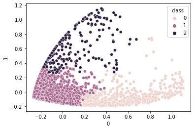

```python
sns.scatterplot(data=pca_data["class"], x=pca_data.iloc[:,0], y=pca_data.iloc[:,1],hue=pca_data["class"])
```

```python
result_data=data.copy()
result_data["class"]=y_h
ccdict= {1:"<5000" ,2:"5,000 - 10,000" ,3:"10,001 - 25,000",4:"25,001 - 50,000",5:">50,000"}

result_data["cc1_miles"]=result_data['cc1_miles'].replace(ccdict)
result_data["cc2_miles"]=result_data['cc2_miles'].replace(ccdict)
result_data["cc3_miles"]=result_data['cc3_miles'].replace(ccdict)

result_data.head()
```

|  | Balance | Qual_miles | cc1_miles | cc2_miles | cc3_miles | Bonus_miles | Bonus_trans | Flight_miles_12mo | Flight_trans_12 | Days_since_enroll | Award | class |
| --- | --- | --- | --- | --- | --- | --- | --- | --- | --- | --- | --- | --- |
| 0 | 28143 | 0 | <5000 | <5000 | <5000 | 174 | 1 | 0 | 0 | 7000 | 0 | 1 |
| 1 | 19244 | 0 | <5000 | <5000 | <5000 | 215 | 2 | 0 | 0 | 6968 | 0 | 1 |
| 2 | 41354 | 0 | <5000 | <5000 | <5000 | 4123 | 4 | 0 | 0 | 7034 | 0 | 1 |
| 3 | 14776 | 0 | <5000 | <5000 | <5000 | 500 | 1 | 0 | 0 | 6952 | 0 | 1 |
| 4 | 97752 | 0 | 25,001 - 50,000 | <5000 | <5000 | 43300 | 26 | 2077 | 4 | 6935 | 1 | 1 |

```python
data.columns
```

```
Index(['Balance', 'Qual_miles', 'cc1_miles', 'cc2_miles', 'cc3_miles',
       'Bonus_miles', 'Bonus_trans', 'Flight_miles_12mo', 'Flight_trans_12',
       'Days_since_enroll', 'Award'],
      dtype='object')
```

# Question 2

Compare the cluster centroids to characterize the different clusters and try to give each cluster a label

```python
result_data.groupby("class").mean()
```

| class | Balance | Qual_miles | Bonus_miles | Bonus_trans | Flight_miles_12mo | Flight_trans_12 | Days_since_enroll | Award |
| --- | --- | --- | --- | --- | --- | --- | --- | --- |
| 0 | 43336.086705 | 72.118497 | 38937.027457 | 17.135838 | 358.281792 | 1.083815 | 4163.491329 | 0.744220 |
| 1 | 75391.622707 | 106.906196 | 11760.399100 | 10.125995 | 319.772240 | 0.936310 | 3980.595362 | 0.271720 |
| 2 | 5361.020325 | 8.150407 | 792.593496 | 2.682927 | 64.792683 | 0.186992 | 4847.227642 | 0.162602 |

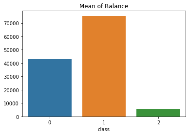

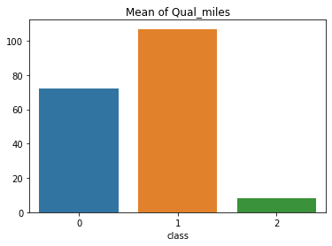

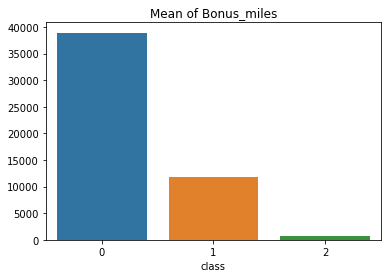

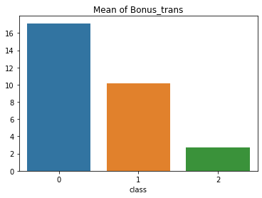

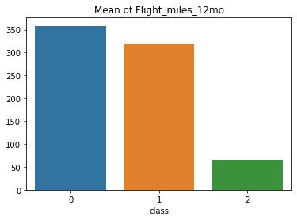

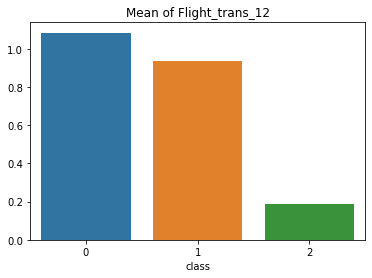

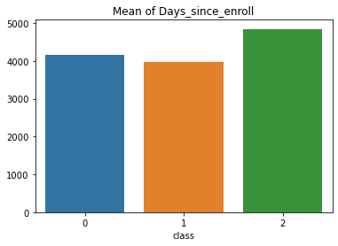

```python
import warnings
warnings.filterwarnings("ignore")
columns= ['Balance', 'Qual_miles', 'Bonus_miles', 'Bonus_trans', 'Flight_miles_12mo', 'Flight_trans_12',
       'Days_since_enroll']
for each in columns:
    x=result_data.groupby("class").mean()[each].index
    y=result_data.groupby("class").mean()[each].values
    plt.title("Mean of " + each)
    sns.barplot(x,y)
    plt.show()
```

```
cc1_miles
```

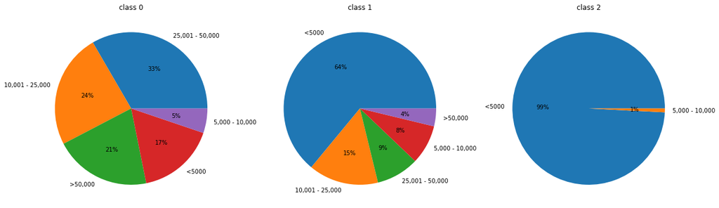

```
cc2_miles
```

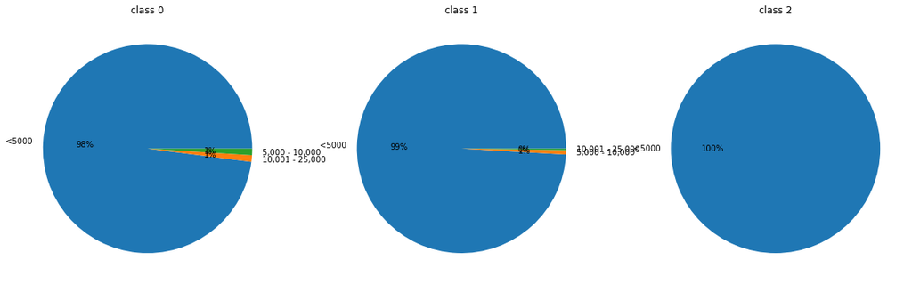

```
cc3_miles
```

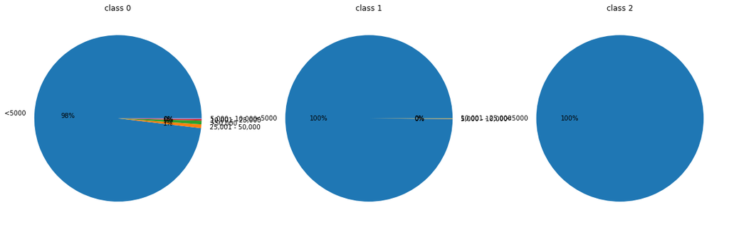

```python
columns= ['cc1_miles', 'cc2_miles', 'cc3_miles']

from matplotlib.pyplot import figure



for each in columns:
    a=1
    res_data=result_data.groupby("class")[each].value_counts()
    print(each)
    figure(figsize=(20, 50))

    for i in range(0,3):
        plt.subplot(a, 3,i+1)
        plt.title("class "+str(i))
        plt.pie(res_data[i].values, labels =res_data[i].index, autopct='%.0f%%')

    plt.show()
    a=a+1
```

only cc1_miles is distinctive  
Although the balance of class 1 is **high**, the **low activity** in the last 12 months draws attention.

# Question 3

To check the stability of the clusters, remove a random 5% of the data (by taking a random sample of 95% of the records, namely 200 records), and repeat the analysis. Does the same picture emerge? Use 425 as the seed.

[random.seed()](https://www.geeksforgeeks.org/random-seed-in-python/)

[df.sample()](https://datatofish.com/random-rows-pandas-dataframe/)

```python
import random
random.seed(425)
data_scaled_sample=data_scaled.sample(frac=0.95)
```

```python
from sklearn.cluster import AgglomerativeClustering
cluster = AgglomerativeClustering(n_clusters=3, affinity='euclidean', linkage='complete')
y_s=cluster.fit_predict(data_scaled_sample)
from sklearn.decomposition import PCA
pca = PCA(n_components=2)
pca_data_sample=pca.fit_transform(data_scaled_sample)
pca_data_sample=pd.DataFrame(pca_data_sample)
pca_data_sample["class"]=y_s
```

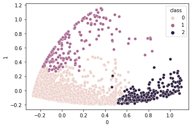

```python
sns.scatterplot(data=pca_data_sample["class"], x=pca_data_sample.iloc[:,0], y=pca_data_sample.iloc[:,1],hue=pca_data_sample["class"])
```

# Question 4

Use k-means algorithm with the number of clusters you found in part (a). Does the same picture emerge?

To process the learning data, the K-means algorithm in data mining starts with a first group of randomly selected centroids, which are used as the beginning points for every cluster, and then performs iterative (repetitive) calculations to optimize the positions of the centroids

```python
Kmean = KMeans(n_clusters=3, )
Kmean.fit(data_scaled)
pca_data["K_class"]=Kmean.predict(data_scaled)
result_data["K_class"]=Kmean.predict(data_scaled)
silhouette_avg = silhouette_score(data_scaled,Kmean.predict(data_scaled))
print(silhouette_avg)
```

```
0.5692140234171399
```

```python
print("Hierarchical Clustering classes\n",pca_data["class"].value_counts())
print("K_means Clustering classes\n",pca_data["K_class"].value_counts())
```

```
Hierarchical Clustering classes
 1    2889
0     692
2     246
Name: class, dtype: int64
K_means Clustering classes
 1    2805
0     779
2     243
Name: K_class, dtype: int64
```

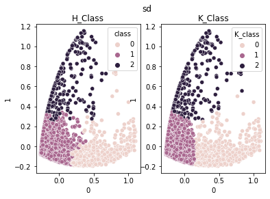

```python
f, axes = plt.subplots(1, 2)
plt.suptitle("sd")
sns.scatterplot(data=pca_data["class"], x=pca_data.iloc[:,0], y=pca_data.iloc[:,1],hue=pca_data["class"],ax=axes[0])
sns.scatterplot(data=pca_data["K_class"], x=pca_data.iloc[:,0], y=pca_data.iloc[:,1],hue=pca_data["K_class"],ax=axes[1])

axes[0].set_title('H_Class')
axes[1].set_title('K_Class')
plt.show()
```

```python
result_data.groupby("K_class").mean()
```

| K_class | Balance | Qual_miles | Bonus_miles | Bonus_trans | Flight_miles_12mo | Flight_trans_12 | Days_since_enroll | Award | class |
| --- | --- | --- | --- | --- | --- | --- | --- | --- | --- |
| 0 | 44839.600770 | 81.174583 | 37709.587933 | 16.976893 | 360.400513 | 1.078306 | 4135.064185 | 0.711168 | 0.121951 |
| 1 | 75915.601426 | 105.355793 | 11239.485205 | 9.924777 | 317.595365 | 0.931907 | 3984.460606 | 0.264171 | 1.004991 |
| 2 | 5104.814815 | 8.251029 | 875.181070 | 2.913580 | 66.193416 | 0.193416 | 4838.958848 | 0.185185 | 1.921811 |

Although there are similar pictures, the hierarchical clustering algorithm allocates a little more **sharply** to the averages.

# Question 5

Which clusters would you target for offers, and what type of offers would you target to customers in that cluster?

### Loyal Customer( Class 0)

it is the most trouble-free class and it is the class that current campaigns appeal to the most. This situation must be maintained

### Customers with Losing Their Habit(Class 1)

It is the class that should be the most focused because, despite the bonuses it has accumulated, its use in the last 12 months is in contrast. This shows that it must be won again. The customer should be reminded of the miles they have with various advertisements and should be encouraged to spend them. In addition, in order to increase the use of the card, campaigns should be offered based on their past actions.

### Passive Customers(Class 2 )

These customers consist of customers who have used the card very little. At the same rate, flight miles are noticeably less. 2 To focus on. it's class. The customer should be encouraged to use the card with aggressive Campaigns

Gökhan Kutay Civelek 090180352  
Doğuhan Altın 090180336